# What is Population Ecology?

1 7 2020

## What is population ecology?

Population ecology:

The dynamics of species populations and how these populations interact with the environment

## What is a population?

- A population is a all the individuals from a single species within an ecological community

## Why do we study it?

- In population ecology we are interested in growth, fluctuations, spread, interactions (within and between populations)
- What information might we need to gather?
- How would you measure population ecology?

## Population change

- Methods to predict population change differ depending on whether reproduction only occurs seasonally, or whether it is continuous
- Geometric and exponential rates of growth
- Determining when exponential growth occurs

## Population growth

- Some species only breed once a year, with a distinct discrete breeding season. e.g. Most invertebrates, plants, mammals “Geometric growth”
- Other species can breed at any time, so that the populations show continuous growth e.g. bacteria, primates “Exponential growth”
- Different methods to predict populations

## Population growth (2)

- Imagine population of 2 animals, producing 2 offspring
- Ignore Death, Emmigration and Immigration

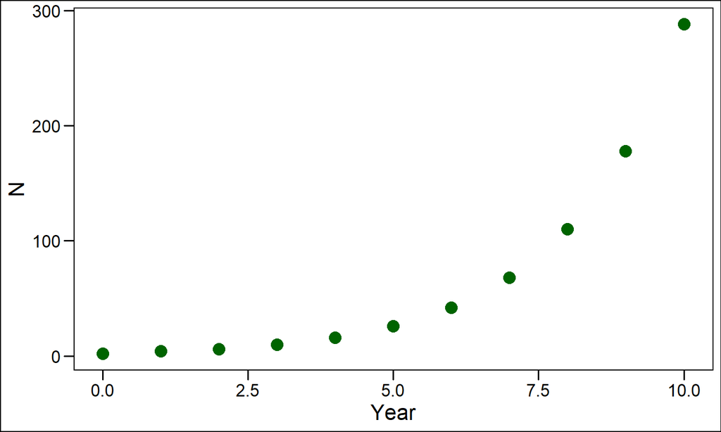

## Population breeds seasonally (i.e. at discrete time intervals)

- Population growth is described using difference equations
- Difference equations show the relationship between the population size at the start compared to the population at the end of one timestep
- Timestep is usually a year etc.
- Geometric growth if population unlimited

## Equation in words

Pop. at end of timestep = Pop. at start of timestep x Discrete per capita net growth rate

## Discrete breeding - unlimited population growth equation

Nt+1 = λ.Nt

Nt population size at time t (this year)

Nt+1 population size at time t+1 (next year)

λ finite rate of population increase, or discrete (per capita) net rate of growth, or geometric growth rate (births-deaths)

t is the time period (e.g. in years)

## What is λ ?

- λ (Greek symbol ‘lambda’) is the growth rate per head, and is any number greater than zero
- Note that values of λ less than 1 result in population decline, so the term ‘growth’ rate is a little confusing.
- Some textbooks use R instead of λ

𝜆= 𝑁_(𝑡+1)/𝑁_𝑡

## Population size after discrete (seasonal) reproduction over many years

- If you had two timesteps, then
- Nt+2 = λ.Nt+1
- which is the same as
- Nt+2 = λ.λ.Nt = λ2.Nt
- so that the generalised form for any number of years (T) is:

NT = λT .N0

## Species breeds all year (continuous reproduction)

- Population growth in these animals is usually described with differential equations
- Differential equations describe rates of change
- Exponential growth if population unlimited

## Equation in words

Rate of increase in population = (Average per capita birth rate - average per capita death rate) x Current population size

## Continuous breeding: unlimited population growth equation

𝑑𝑁/𝑑𝑡=(𝐵−𝐷)𝑁

𝑑𝑁/𝑑𝑡=𝑟𝑁

dN = change in population size

dt = change in time

dN/dt = rate of change in population

r = instantaneous rate of population growth

## λ versus r

- Note that λ and r are not the same!
- λ = exp(r) or r = ln(λ)
- λ only compounds once a year, whereas r compounds instantaneously
- So, for example, if λ is 1.2 then the equivalent growth rate in r is only 0.18
- Think of bank interest rates on monthly vs annual accounts

## Population size after continuous reproduction over many years

Continuous population growth after a set period of time can be predicted from:

𝑁_𝑡=𝑁_0 𝑒^𝑟𝑡

where:

N0 = Population at start

Nt = Population at time t

r = instantaneous population growth rate

e = Euler’s number for natural logarithm 2.718…

## Limited population growth

- In reality no population can grow indefinitely
- Values of λ or r fluctuate both independent and dependent on the density of the population
- Eventually density-dependent will limit growth; observed in a wide range of taxa and habitats
- Carrying capacity K must be considered

## Intraspecific competition: discrete breeding

Intraspecific competition can be represented by the discrete logistic growth equation

𝑁_(𝑡+1)=𝜆𝑁_𝑡 (1−𝑁_𝑡/𝐾)

where K = carrying capacity λ = net reproductive rate

## Intraspecific competition: continuous breeding

Logistic growth equation for continuous growth:

𝑑𝑁/𝑑𝑡=𝑟𝑁(1−𝑁/𝐾)

where K = carrying capacity r = instantaneous population growth rate

## Can human carrying capacity be predicted?

- How will human population growth level off to a steady rate?
- Problem of aging population as reproductive rate slows
- Development – demand on resources by Developed and Developing countries
- Attempt by Pearl & Reed (1920) to estimate K in USA

## Inverse density dependence

- So far we have only considered populations where increasing population size results in a decline in population growth rates.
- Density dependence usually has a regulating effect, so that the population tends towards its carrying capacity.
- Inverse density dependence occurs where population growth rates fall as the population size declines.
- THIS IS DESTABILISING AND CAN DRIVE ENDANGERED POPULATION TOWARDS EXTINCTION!